# Actividad 3

# Rotación de cargo

En una organización, se busca comprender y prever los factores que influyen en la rotación de empleados entre distintos cargos. La empresa ha recopilado datos históricos sobre el empleo de sus trabajadores, incluyendo variables como la antigüedad en el cargo actual, el nivel de satisfacción laboral, el salario actual, edad y otros factores relevantes. La gerencia planea desarrollar un modelo de regresión logística que permita estimar la probabilidad de que un empleado cambie de cargo en el próximo período y determinar cuales factores indicen en mayor proporción a estos cambios.

Con esta información, la empresa podrá tomar medidas proactivas para retener a su talento clave, identificar áreas de mejora en la gestión de recursos humanos y fomentar un ambiente laboral más estable y tranquilo. La predicción de la probabilidad de rotación de empleados ayudará a la empresa a tomar decisiones estratégicas informadas y a mantener un equipo de trabajo comprometido y satisfecho en sus roles actuales.

A continuación se describen los pasos que la gerencia ha propuesto para el análisis:

El proposito del analisis es desarrollar un modelo que permita identificar los factores mas asociados a los cambios de cargo y apoyar la toma de decisiones estrategicas en la organizacion.

El conjunto de datos está compuesto por aproximadamente 23 variables, por lo que realizar un análisis detallado de cada una de ellas no resulta eficiente ni alineado con el objetivo del proyecto. En este contexto, se llevó a cabo un proceso de selección de variables orientado a identificar aquellas con mayor capacidad explicativa respecto a la rotación de empleados.

Este proceso se desarrolló a partir de dos enfoques complementarios. En primer lugar, se incorporó el criterio de negocio, identificando variables que, desde la perspectiva de la gestión del talento humano, podrían estar relacionadas con la rotación, tales como las condiciones laborales, el tipo de cargo y las características individuales de los empleados. En segundo lugar, se realizó una exploracion estadística preliminar, mediante el cual se evaluó la relación individual entre cada variable y la variable objetivo, permitiendo priorizar aquellas con mayor evidencia de asociación.

La combinación de estos enfoques permitió realizar una selección más robusta, evitando depender exclusivamente del criterio subjetivo o de los resultados estadísticos aislados. Como resultado, se seleccionaron seis variables para el análisis detallado, distribuidas en tres categóricas y tres numéricas, lo que permite abordar el fenómeno de rotación desde diferentes dimensiones y facilita una interpretación más clara en las etapas posteriores del análisis y modelado.

### 1.1. Distribución del ingreso mensual de los empleados

La distribución del ingreso mensual revela una asimetría positiva o sesgo a la derecha, comportamiento esperado y común en variables salariales dentro de cualquier organización. La mayor concentración de empleados se ubica en el rango de 2.000 a 3.000, con aproximadamente 360 personas, lo que indica que la mayoría de la plantilla percibe salarios relativamente bajos. A medida que el ingreso aumenta, la frecuencia disminuye de forma sostenida, reflejando la estructura jerárquica típica de una empresa donde los salarios altos corresponden a una minoría. En este sentido, la mediana resulta una medida más representativa que la media, ya que esta última tiende a inflarse por los valores extremos del extremo superior. Adicionalmente, se observa un repunte en el rango de 19.000 a 20.000, que responde de forma natural a la presencia de cargos de mayor jerarquía como directores y ejecutivos, quienes representan una proporción pequeña pero diferenciada dentro de la organización. Dado este comportamiento asimétrico, se utilizará la variable **log_ingresos** en el modelo, transformación que ya fue aplicada durante el preprocesamiento y que permite estabilizar la varianza y mejorar el ajuste de la regresión logística.

[interactive chart not shown]

### 1.2. Distribución de la antigüedad en el cargo de los empleados

La distribución de la antigüedad en el cargo muestra que la mayor proporción de empleados se concentra en los rangos de 2 a 3 años (34.5%) y 6 o más años (35.5%), lo que sugiere la coexistencia de dos grupos predominantes: empleados relativamente recientes y empleados con alta permanencia en la organización. Por otro lado, se observa una menor participación en el rango de 4 a 5 años (9.5%), lo que podría indicar una posible transición o reducción en ese tramo intermedio. Asimismo, el 20.5% de los empleados presenta una antigüedad de 0 a 1 año, lo que refleja una proporción relevante de personal con corta permanencia. En conjunto, estos patrones evidencian una distribución no uniforme de la antigüedad, lo que podría ser consistente con dinámicas de rotación o retención diferenciadas, aunque sin permitir inferir causas específicas en esta etapa del análisis.

[interactive chart not shown]

### 1.3. Distribución de la satisfacción laboral de los empleados

La distribución de la satisfacción laboral muestra que la mayor proporción de empleados se concentra en los niveles 3 (30.1%) y 4 (31.2%), lo que indica una tendencia general hacia niveles de satisfacción relativamente altos dentro de la organización. Por otro lado, los niveles más bajos de satisfacción, correspondientes a 1 (19.7%) y 2 (19.0%), presentan una menor participación, aunque en conjunto representan cerca del 40% de los empleados. En términos generales, la variable evidencia una distribución inclinada hacia valores altos, sin presentar concentraciones extremas en un solo nivel, lo que sugiere una dispersión moderada en los niveles de satisfacción laboral.

[interactive chart not shown]

### 1.4. Distribución de las horas extra de los empleados

La distribución de las horas extra muestra que la mayoría de los empleados, equivalente al 71.7%, no realiza horas adicionales, mientras que el 28.3% sí reporta trabajar horas extra. Esta diferencia evidencia una clara predominancia de empleados que mantienen su jornada laboral dentro de los horarios establecidos. No obstante, la proporción de empleados que realiza horas extra es significativa, representando cerca de un tercio de la población, lo que indica que este comportamiento no es marginal dentro de la organización. En conjunto, la variable presenta una distribución desbalanceada hacia la categoría “No”, aunque conserva una participación relevante en la categoría “Sí”.

[interactive chart not shown]

### 1.5. Distribución de cargo de los empleados

La distribución por cargo evidencia que la mayor proporción de empleados se concentra en los roles de Ejecutivo de Ventas (22.2%), Investigador Científico (19.9%) y Técnico de Laboratorio (17.6%), los cuales en conjunto representan una parte significativa de la población analizada. En contraste, otros cargos como Director de Manufactura (9.9%) y Representante de Salud (8.9%) presentan una participación intermedia, mientras que posiciones como Gerente (6.9%), Representante de Ventas (5.6%), Director de Investigación (5.4%) y Recursos Humanos (3.5%) muestran una menor proporción relativa. En general, la variable presenta una distribución heterogénea, con una clara concentración en ciertos cargos operativos y comerciales, y una menor representación en roles directivos o especializados.

[interactive chart not shown]

### 1.6. Distribucion de viaje de negocios del empleado

La distribución de los viajes de negocios muestra que la mayoría de los empleados, equivalente al 71%, realiza viajes de manera rara vez, lo que indica que esta es la condición predominante dentro de la organización. Por otro lado, el 18.8% de los empleados viaja frecuentemente, mientras que una proporción menor, correspondiente al 10.2%, no realiza viajes de negocio. En conjunto, la variable presenta una clara concentración en la categoría intermedia, con menor participación en los extremos, lo que sugiere que la mayor parte del personal tiene una exposición ocasional a desplazamientos laborales.

[interactive chart not shown]

### 2.1. Rotación de empleados según la realización de horas extra

La variable horas extra presenta el mayor impacto observado en el análisis bivariado, evidenciando una diferencia de aproximadamente 20 puntos porcentuales en la proporción de rotación entre los grupos. En particular, los empleados que no realizan horas extra muestran una rotación del 10.4%, mientras que aquellos que sí las realizan alcanzan un 30.5%. Esta diferencia posiciona a las horas extra como la variable con mayor capacidad explicativa dentro del conjunto analizado, estableciendo un punto de referencia para la comparación con las demás variables.

[interactive chart not shown]

### 2.2. Rotación de empleados según el nivel de satisfacción laboral

El análisis de la rotación según el nivel de satisfacción laboral evidencia una relación inversa entre ambas variables, donde la proporción de rotación disminuye a medida que aumenta el nivel de satisfacción. En particular, los empleados con menor satisfacción (nivel 1) presentan una rotación de 22.8%, mientras que aquellos con mayor satisfacción (nivel 4) muestran una proporción considerablemente menor de 11.3%, lo que representa una diferencia aproximada de 11.5 puntos porcentuales. Si bien esta variable presenta un impacto relevante, su magnitud es inferior a la observada en las horas extra, que muestran una diferencia cercana a los 20 puntos porcentuales. No obstante, el comportamiento progresivo y consistente de la satisfacción laboral la posiciona como una de las variables más influyentes en la explicación de la rotación.

[interactive chart not shown]

### 2.3. Rotación de empleados según el grupo de cargo

El análisis de la rotación según el grupo de cargo evidencia diferencias relevantes entre los distintos roles dentro de la organización. En particular, se observa que grupos como Técnico de Laboratorio y Recursos Humanos presentan las mayores proporciones de rotación, con valores cercanos al 23.9% y 23.1%, respectivamente, mientras que el grupo de “Otros” muestra una proporción considerablemente menor, alrededor del 9.7%. Esta diferencia representa aproximadamente 14 puntos porcentuales entre los extremos, lo que posiciona al cargo como una variable de impacto medio-alto en la explicación de la rotación. En comparación con otras variables, este efecto es inferior al observado en las horas extra, pero superior al de la satisfacción laboral, evidenciando que el rol desempeñado dentro de la organización influye de manera importante, aunque no predominante, en la probabilidad de rotación.

[interactive chart not shown]

### 2.4. Rotación de empleados según la frecuencia de viajes de negocio

El análisis de la rotación según la frecuencia de viajes de negocios evidencia una relación creciente y consistente entre ambas variables. En particular, los empleados que no realizan viajes presentan una proporción de rotación del 8.0%, mientras que aquellos que viajan frecuentemente alcanzan valores cercanos al 24.9%, lo que representa una diferencia aproximada de 16.9 puntos porcentuales entre los extremos. Esta magnitud posiciona a los viajes de negocio como una de las variables con mayor impacto en la rotación, ubicándose por debajo de las horas extra, pero por encima de variables como el cargo y la satisfacción laboral. Asimismo, el comportamiento progresivo observado entre las categorías refuerza la consistencia de esta relación, evidenciando que una mayor exposición a viajes se asocia con un incremento sostenido en la probabilidad de rotación.

[interactive chart not shown]

### 2.5. Distribución del logaritmo de los ingresos según la rotación

El análisis de la distribución del logaritmo de los ingresos según la rotación evidencia diferencias claras entre ambos grupos. Los empleados que no presentan rotación muestran una media de 8.61, mientras que aquellos que sí rotan presentan una media inferior de 8.25, lo que representa una diferencia aproximada de 0.36 unidades en escala logarítmica. Esta diferencia, consistente tanto en la media como en la mediana, indica que los empleados con menores niveles de ingreso presentan una mayor probabilidad de rotación. En comparación con otras variables analizadas, el impacto de los ingresos es moderado, siendo inferior al observado en variables como horas extra, viajes de negocio y cargo, pero superior al de variables con menor capacidad explicativa como la antigüedad. En conjunto, estos resultados posicionan a los ingresos como un factor relevante, aunque no predominante, en la explicación de la rotación.

[interactive chart not shown]

### 2.6. Distribución de la antigüedad en el cargo según la rotación

El análisis de la antigüedad en el cargo según la rotación evidencia una relación inversa y progresiva entre ambas variables. En particular, los empleados con menor antigüedad (0–1 años) presentan una proporción de rotación de aproximadamente 27.9%, mientras que aquellos con mayor permanencia (6+ años) muestran una proporción considerablemente menor, cercana al 10.2%, lo que representa una diferencia aproximada de 17.7 puntos porcentuales. No obstante, este comportamiento debe interpretarse con cautela, ya que responde a un patrón estructural en el que los empleados más nuevos presentan naturalmente mayor probabilidad de salida. En este sentido, aunque la magnitud de la diferencia es elevada, el efecto observado es progresivo y menos abrupto en comparación con variables como horas extra o viajes de negocio. Asimismo, el análisis mediante boxplot muestra una alta superposición entre los grupos y diferencias moderadas en las medianas, lo que sugiere una menor capacidad discriminante directa. En conjunto, estos resultados posicionan a la antigüedad como una variable de impacto medio, relevante en la explicación de la rotación, pero no predominante dentro del conjunto analizado.

La antigüedad no es causa directa, sino condición estructural del ciclo del empleado.

[interactive chart not shown]

### 2.7. Variables más influyentes en la rotación de empleados

En términos generales, los resultados sugieren que la rotación está más asociada a condiciones operativas y de experiencia laboral, como la carga de trabajo y la dinámica de desplazamiento, que a variables estructurales como la antigüedad o el rol dentro de la organización.

[interactive chart not shown]

### 3.1. Descripción del modelo

Se construyó un modelo de regresión logística con el objetivo de estimar la probabilidad de rotación de los empleados a partir de variables previamente seleccionadas en el análisis exploratorio. Las variables incluidas en el modelo fueron: horas extra, grupo de cargo, frecuencia de viajes de negocio, satisfacción laboral, logaritmo de los ingresos y antigüedad en el cargo. Estas variables fueron seleccionadas con base en su relevancia observada en el análisis bivariado y su capacidad explicativa en relación con la rotación.

### 3.2. Evaluación del modelo

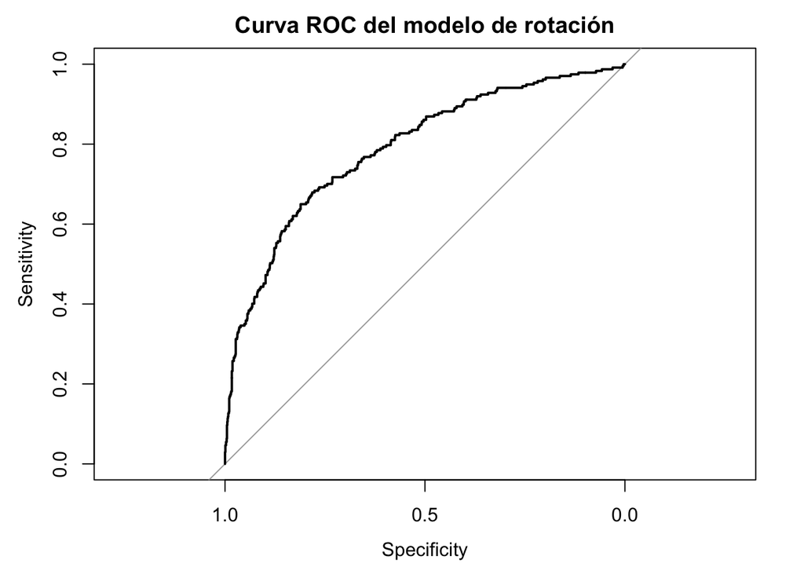

El modelo presenta un desempeño adecuado, evidenciado por una reducción significativa de la devianza respecto al modelo nulo, lo que indica una mejora en la capacidad explicativa. Asimismo, el área bajo la curva ROC (AUC) es aproximadamente 0.79, lo que refleja una buena capacidad de discriminación entre empleados que rotan y aquellos que permanecen en la organización.

### 3.3. Importancia de las variables (Odds Ratio)

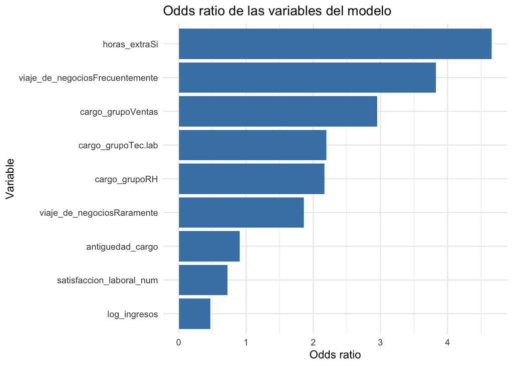

El análisis de los odds ratio permite interpretar el impacto de cada variable sobre la probabilidad de rotación. En este sentido, las horas extra se posicionan como el factor de mayor influencia, incrementando significativamente la probabilidad de salida de los empleados. De igual manera, la frecuencia de viajes de negocio, especialmente en niveles altos, muestra un efecto positivo relevante sobre la rotación.

Por otro lado, variables como la satisfacción laboral y el nivel de ingresos presentan una relación inversa con la rotación, actuando como factores protectores. A medida que aumentan estos valores, la probabilidad de rotación disminuye. En cuanto al grupo de cargo, se observan diferencias en la probabilidad de rotación dependiendo del rol, lo que sugiere un efecto heterogéneo. Finalmente, la antigüedad en el cargo presenta un impacto negativo de menor magnitud, consistente con su carácter estructural.

### 3.4. Distribución de probabilidades predichas

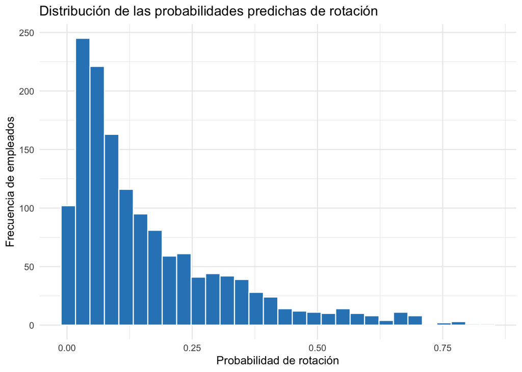

La distribución de las probabilidades predichas muestra que la mayoría de los empleados presentan una baja probabilidad de rotación, concentrándose en valores cercanos a cero. Sin embargo, se observa una cola hacia valores más altos, lo que indica la presencia de un grupo reducido de empleados con mayor riesgo de salida.

Este comportamiento sugiere que el modelo es conservador en sus predicciones, priorizando la precisión en la clase mayoritaria, pero con menor capacidad para identificar correctamente los casos de rotación.

### 3.5. Interpretación del modelo

Los resultados del modelo confirman los hallazgos obtenidos en el análisis exploratorio. En particular, las variables asociadas a condiciones laborales, como las horas extra y la frecuencia de viajes de negocio, presentan el mayor impacto en la probabilidad de rotación. Esto indica que factores relacionados con la carga laboral y la dinámica de trabajo influyen significativamente en la decisión de permanencia de los empleados.

Por otro lado, variables como la satisfacción laboral y los ingresos actúan como elementos estabilizadores, reduciendo la probabilidad de salida. En contraste, la antigüedad en el cargo muestra un efecto más estructural, asociado al ciclo natural del empleado dentro de la organización.

### 3.6. Conclusión del modelo

En conjunto, el modelo de regresión logística presenta un buen desempeño general y una adecuada capacidad explicativa. La coherencia entre los resultados del modelo y el análisis exploratorio refuerza la validez del enfoque utilizado. No obstante, se identifican oportunidades de mejora en la capacidad de clasificación de la rotación, particularmente en la detección de la clase minoritaria.